# Test de Mantel

### Test de Mantel

Ahora relizaremos el test de Mantel comparando así la matriz de distancia euclidianas de la precipatación con la matriz de distancias geográficas.

- **Mantel statistic r:** -0.0008443
- **Significance:** 0.4151

```r
### Concentración vs Geografico
con_geo = mantel(dist.con, dist.geo, method = "spearman", permutations = 9999,
                 na.rm = TRUE)
con_geo
##
## Mantel statistic based on Spearman's rank correlation rho
##
## Call:
## mantel(xdis = dist.con, ydis = dist.geo, method = "spearman",      permutations = 9999, na.rm = TRUE)
##
## Mantel statistic r: -0.0008443
##       Significance: 0.4151
##
## Upper quantiles of permutations (null model):
##    90%    95%  97.5%    99%
## 0.0373 0.0613 0.0613 0.0613
## Permutation: free
## Number of permutations: 9999
```

- El valor de la *estadística de Mantel (r)* indica la fuerza y dirección de la correlación entre las dos matrices de distancias. En este caso, el valor es muy cercano a cero, lo que sugiere que no hay una correlación clara entre la precipitación en Bogotá y la ubicación geográfica.
- Con un **valor de significancia** de 0.4151, no hay suficiente evidencia para rechazar la hipótesis nula. Es decir, no hay suficiente evidencia para afirmar que hay una correlación espacial significativa entre la precipitación y la ubicación geográfica en Bogotá.

## Ejemplo 2: Antioquia

### Filtrado del conjunto de datos

Primeramente lo que se hará con el conjunto de datos de Antioquia es buscar la fecha de la cuál se tengan más datos, teniendo en cuenta que nuestos datos son espacio-temporales.

```r
print(fecha_con_maximo_conteo)
```

```
## [1] "2018-01-01"
```

```r
## Filtrado de fecha: Primero de enero de 2018 ----
precip_a = precip_a[precip_a$Fecha == '2018-01-01',]
precip_a <- precip_a[!is.na(precip_a$Concentración), ]
```

### Filtrado de columnas: Georeferencia y valor de la variable

Ahora solo filtraremos la tabla para la fecha seleccionada, como se muestra a continuación:

```r
head(precip_a)
```

```
##           Latitud  Longitud      Fecha Nombre.del.municipio Concentración
## 16356772 6.252639 -75.56983 2018-01-01             MEDELLÍN             0
## 16356773 6.252639 -75.56983 2018-01-01             MEDELLÍN             0
## 16356774 6.252639 -75.56983 2018-01-01             MEDELLÍN             0
## 16356775 6.252639 -75.56983 2018-01-01             MEDELLÍN             0
## 16356776 6.252639 -75.56983 2018-01-01             MEDELLÍN             0
## 16356777 6.252639 -75.56983 2018-01-01             MEDELLÍN             0
##                       Variable
## 16356772 Precipitación Líquida
## 16356773 Precipitación Líquida
## 16356774 Precipitación Líquida
## 16356775 Precipitación Líquida
## 16356776 Precipitación Líquida
## 16356777 Precipitación Líquida
```

### Test de Mantel

Ahora relizaremos el test de Mantel comparando así la matriz de distancia euclidianas de la precipatación con la matriz de distancias geográficas.

- **Mantel statistic r:** -0.0269
- **Significance:** 0.794

```r
con_geo = mantel(dist.con, dist.geo, method = "spearman", permutations = 9999,
                 na.rm = TRUE)
con_geo
##
## Mantel statistic based on Spearman's rank correlation rho
##
## Call:
## mantel(xdis = dist.con, ydis = dist.geo, method = "spearman",      permutations = 9999, na.rm = TRUE)
##
## Mantel statistic r: -0.0269
##       Significance: 0.794
##
## Upper quantiles of permutations (null model):
##    90%    95%  97.5%    99%
## 0.0426 0.0556 0.0676 0.0811
## Permutation: free
## Number of permutations: 9999
```

- El valor de la *estadística de Mantel (r)* indica la fuerza y dirección de la correlación entre las dos matrices de distancias. En este caso, el valor negativo indica una correlación negativa, lo que sugiere que a medida que aumenta la distancia geográfica entre las ubicaciones, la diferencia en la precipitación disminuye ligeramente.
- Respecto a la *significancia*, un valor de 0.794 indica que no hay evidencia suficiente para rechazar la hipótesis nula. Es decir, no hay suficiente evidencia para afirmar que hay una correlación espacial significativa entre la precipitación en Antioquia y la ubicación geográfica.

### Gráfica de dispersión

A continuación veremos la gráfica de dispersión de la distancia geográfica contrastada con la disimilitud de precipitación.

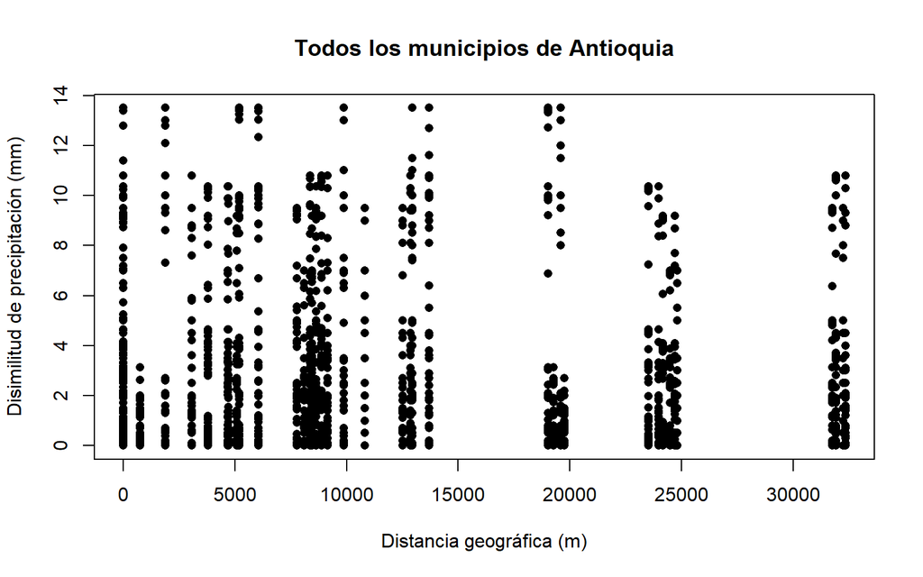

De esta se puede observar que hay agrupaciones en los conjuntos, es un resultado a pesar de interesante, esperado, debido a que alrededor de cada municipio se tendrá una precipitación similar, y se agruparan las precipitaciones a cada zona.

# Referencias

- Paula Moraga. (2024). Spatial Statistics for Data Science. CRC Press.
- Oliver Schabenberger & Carol A. Gotway. (2005). Statistical Methods for Spatial Data Analysis. Chapman & Hall CRC.
- *jkzorz*. (2019). Mantel Test in R. Recuperado de https://jkzorz.github.io/2019/07/08/mantel-test.html